# Risk Factor Analysis

## Outcome Variable

**Outcome Variable:** y_rate_haz

## Predictor Variables

**Intervention Variable:** fhtcm

**Adjustment Set:**

- arm
- W_mage
- W_fage
- meducyrs
- feducyrs
- W_mhtcm
- W_mwtkg
- W_mbmi
- single
- delta_W_fage
- delta_meducyrs
- delta_feducyrs
- delta_W_mhtcm
- delta_W_mwtkg
- delta_W_mbmi
- delta_single

## Stratifying Variables

The analysis was stratified on these variable(s):

- agecat
- studyid
- country

## Data Summary

| agecat | studyid | country | fhtcm | n_cell | n | outcome_variable |
| --- | --- | --- | --- | --- | --- | --- |
| 0-3 months | ki1000304b-SAS-CompFeed | INDIA | >=167 cm | 345 | 765 | y_rate_haz |
| 0-3 months | ki1000304b-SAS-CompFeed | INDIA | <162 cm | 196 | 765 | y_rate_haz |
| 0-3 months | ki1000304b-SAS-CompFeed | INDIA | [162-167) cm | 224 | 765 | y_rate_haz |
| 0-3 months | ki1101329-Keneba | GAMBIA | >=167 cm | 631 | 965 | y_rate_haz |
| 0-3 months | ki1101329-Keneba | GAMBIA | <162 cm | 75 | 965 | y_rate_haz |
| 0-3 months | ki1101329-Keneba | GAMBIA | [162-167) cm | 259 | 965 | y_rate_haz |
| 0-3 months | ki1119695-PROBIT | BELARUS | >=167 cm | 10773 | 11500 | y_rate_haz |
| 0-3 months | ki1119695-PROBIT | BELARUS | <162 cm | 151 | 11500 | y_rate_haz |
| 0-3 months | ki1119695-PROBIT | BELARUS | [162-167) cm | 576 | 11500 | y_rate_haz |
| 0-3 months | ki1135781-COHORTS | GUATEMALA | >=167 cm | 25 | 180 | y_rate_haz |
| 0-3 months | ki1135781-COHORTS | GUATEMALA | <162 cm | 106 | 180 | y_rate_haz |
| 0-3 months | ki1135781-COHORTS | GUATEMALA | [162-167) cm | 49 | 180 | y_rate_haz |
| 3-6 months | ki1000304b-SAS-CompFeed | INDIA | >=167 cm | 308 | 682 | y_rate_haz |
| 3-6 months | ki1000304b-SAS-CompFeed | INDIA | <162 cm | 175 | 682 | y_rate_haz |
| 3-6 months | ki1000304b-SAS-CompFeed | INDIA | [162-167) cm | 199 | 682 | y_rate_haz |
| 3-6 months | ki1101329-Keneba | GAMBIA | >=167 cm | 673 | 1037 | y_rate_haz |
| 3-6 months | ki1101329-Keneba | GAMBIA | <162 cm | 74 | 1037 | y_rate_haz |
| 3-6 months | ki1101329-Keneba | GAMBIA | [162-167) cm | 290 | 1037 | y_rate_haz |
| 3-6 months | ki1119695-PROBIT | BELARUS | >=167 cm | 9473 | 10104 | y_rate_haz |
| 3-6 months | ki1119695-PROBIT | BELARUS | <162 cm | 129 | 10104 | y_rate_haz |
| 3-6 months | ki1119695-PROBIT | BELARUS | [162-167) cm | 502 | 10104 | y_rate_haz |
| 3-6 months | ki1135781-COHORTS | GUATEMALA | >=167 cm | 37 | 261 | y_rate_haz |
| 3-6 months | ki1135781-COHORTS | GUATEMALA | <162 cm | 148 | 261 | y_rate_haz |
| 3-6 months | ki1135781-COHORTS | GUATEMALA | [162-167) cm | 76 | 261 | y_rate_haz |
| 6-9 months | ki1000304b-SAS-CompFeed | INDIA | >=167 cm | 312 | 683 | y_rate_haz |
| 6-9 months | ki1000304b-SAS-CompFeed | INDIA | <162 cm | 167 | 683 | y_rate_haz |
| 6-9 months | ki1000304b-SAS-CompFeed | INDIA | [162-167) cm | 204 | 683 | y_rate_haz |
| 6-9 months | ki1000304b-SAS-FoodSuppl | INDIA | >=167 cm | 89 | 311 | y_rate_haz |
| 6-9 months | ki1000304b-SAS-FoodSuppl | INDIA | <162 cm | 124 | 311 | y_rate_haz |
| 6-9 months | ki1000304b-SAS-FoodSuppl | INDIA | [162-167) cm | 98 | 311 | y_rate_haz |

[output cut: 72 more lines]

The following strata were considered:

- agecat: 0-3 months, studyid: ki1000304b-SAS-CompFeed, country: INDIA
- agecat: 0-3 months, studyid: ki1101329-Keneba, country: GAMBIA
- agecat: 0-3 months, studyid: ki1119695-PROBIT, country: BELARUS
- agecat: 0-3 months, studyid: ki1135781-COHORTS, country: GUATEMALA
- agecat: 12-15 months, studyid: ki1000304b-SAS-CompFeed, country: INDIA
- agecat: 12-15 months, studyid: ki1000304b-SAS-FoodSuppl, country: INDIA
- agecat: 12-15 months, studyid: ki1101329-Keneba, country: GAMBIA
- agecat: 12-15 months, studyid: ki1119695-PROBIT, country: BELARUS
- agecat: 12-15 months, studyid: ki1135781-COHORTS, country: GUATEMALA
- agecat: 15-18 months, studyid: ki1000304b-SAS-CompFeed, country: INDIA
- agecat: 15-18 months, studyid: ki1000304b-SAS-FoodSuppl, country: INDIA
- agecat: 15-18 months, studyid: ki1101329-Keneba, country: GAMBIA
- agecat: 15-18 months, studyid: ki1119695-PROBIT, country: BELARUS
- agecat: 15-18 months, studyid: ki1135781-COHORTS, country: GUATEMALA
- agecat: 18-21 months, studyid: ki1101329-Keneba, country: GAMBIA
- agecat: 18-21 months, studyid: ki1119695-PROBIT, country: BELARUS
- agecat: 18-21 months, studyid: ki1135781-COHORTS, country: GUATEMALA
- agecat: 21-24 months, studyid: ki1101329-Keneba, country: GAMBIA
- agecat: 21-24 months, studyid: ki1119695-PROBIT, country: BELARUS
- agecat: 21-24 months, studyid: ki1135781-COHORTS, country: GUATEMALA
- agecat: 3-6 months, studyid: ki1000304b-SAS-CompFeed, country: INDIA
- agecat: 3-6 months, studyid: ki1101329-Keneba, country: GAMBIA
- agecat: 3-6 months, studyid: ki1119695-PROBIT, country: BELARUS
- agecat: 3-6 months, studyid: ki1135781-COHORTS, country: GUATEMALA
- agecat: 6-9 months, studyid: ki1000304b-SAS-CompFeed, country: INDIA
- agecat: 6-9 months, studyid: ki1000304b-SAS-FoodSuppl, country: INDIA
- agecat: 6-9 months, studyid: ki1101329-Keneba, country: GAMBIA
- agecat: 6-9 months, studyid: ki1119695-PROBIT, country: BELARUS
- agecat: 6-9 months, studyid: ki1135781-COHORTS, country: GUATEMALA
- agecat: 9-12 months, studyid: ki1000304b-SAS-CompFeed, country: INDIA
- agecat: 9-12 months, studyid: ki1000304b-SAS-FoodSuppl, country: INDIA
- agecat: 9-12 months, studyid: ki1101329-Keneba, country: GAMBIA
- agecat: 9-12 months, studyid: ki1119695-PROBIT, country: BELARUS
- agecat: 9-12 months, studyid: ki1135781-COHORTS, country: GUATEMALA

### Dropped Strata

Some strata were dropped due to rare outcomes:

- agecat: 15-18 months, studyid: ki1119695-PROBIT, country: BELARUS
- agecat: 18-21 months, studyid: ki1119695-PROBIT, country: BELARUS
- agecat: 21-24 months, studyid: ki1119695-PROBIT, country: BELARUS

## Methods Detail

We’re interested in the causal parameters $E[Y_a]$ for all values of $a \in \mathcal{A}$. These parameters represent the mean outcome if, possibly contrary to fact, we intervened to set all units to have $A=a$. Under the randomization and positivity assumptions, these are identified by the statistical parameters $\psi_a=E_W[E_{Y|A,W}(Y|A=a,W)]$. In addition, we’re interested in the mean of $Y$, $E[Y]$ under no intervention (the observed mean). We will estimate these parameters by using SuperLearner to fit the relevant likelihood factors – $E_{Y|A,W}(Y|A=a,W)$ and $p(A=a|W)$, and then updating our likelihood fit using a joint TMLE.

For unadjusted analyses ($W=\{\}$), initial likelihoods were estimated using Lrnr_glm to estimate the simple $E(Y|A)$ and Lrnr_mean to estimate $p(A)$. For adjusted analyses, a small library containing Lrnr_glmnet, Lrnr_xgboost, and Lrnr_mean was used.

Having estimated these parameters, we will then use the delta method to estimate relative risks and attributable risks relative to a prespecified baseline level of $A$.

# Results Detail

## Results Plots

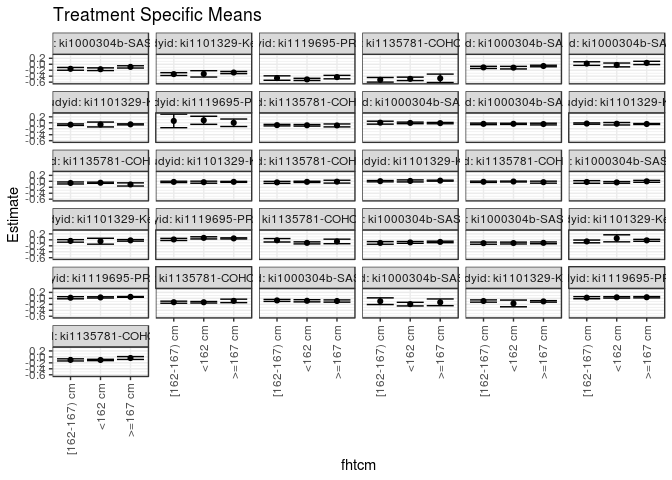

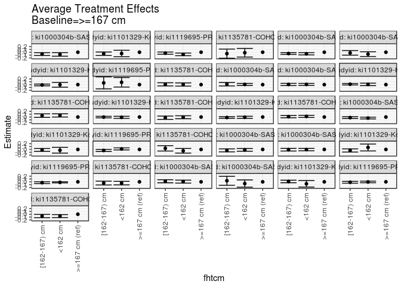

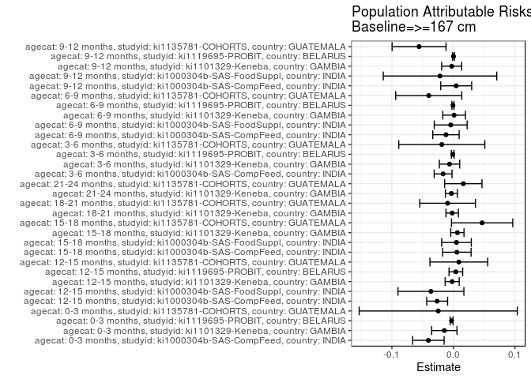

## Results Table

### Parameter: TSM

| agecat | studyid | country | intervention_level | baseline_level | estimate | ci_lower | ci_upper |
| --- | --- | --- | --- | --- | --- | --- | --- |
| 0-3 months | ki1000304b-SAS-CompFeed | INDIA | >=167 cm | NA | -0.0886004 | -0.1261193 | -0.0510814 |
| 0-3 months | ki1000304b-SAS-CompFeed | INDIA | <162 cm | NA | -0.1666937 | -0.2119788 | -0.1214085 |
| 0-3 months | ki1000304b-SAS-CompFeed | INDIA | [162-167) cm | NA | -0.1537406 | -0.1998319 | -0.1076494 |
| 0-3 months | ki1101329-Keneba | GAMBIA | >=167 cm | NA | -0.2777496 | -0.3137254 | -0.2417737 |
| 0-3 months | ki1101329-Keneba | GAMBIA | <162 cm | NA | -0.3221433 | -0.4285154 | -0.2157711 |
| 0-3 months | ki1101329-Keneba | GAMBIA | [162-167) cm | NA | -0.3301069 | -0.3776826 | -0.2825311 |
| 0-3 months | ki1119695-PROBIT | BELARUS | >=167 cm | NA | -0.4312000 | -0.4891351 | -0.3732649 |
| 0-3 months | ki1119695-PROBIT | BELARUS | <162 cm | NA | -0.5080466 | -0.5438311 | -0.4722622 |
| 0-3 months | ki1119695-PROBIT | BELARUS | [162-167) cm | NA | -0.4627241 | -0.5372148 | -0.3882334 |
| 0-3 months | ki1135781-COHORTS | GUATEMALA | >=167 cm | NA | -0.4709779 | -0.6119595 | -0.3299963 |
| 0-3 months | ki1135781-COHORTS | GUATEMALA | <162 cm | NA | -0.4895031 | -0.5471215 | -0.4318848 |
| 0-3 months | ki1135781-COHORTS | GUATEMALA | [162-167) cm | NA | -0.5213844 | -0.5995733 | -0.4431955 |
| 3-6 months | ki1000304b-SAS-CompFeed | INDIA | >=167 cm | NA | -0.0003947 | -0.0330364 | 0.0322469 |
| 3-6 months | ki1000304b-SAS-CompFeed | INDIA | <162 cm | NA | -0.0372189 | -0.0651602 | -0.0092776 |
| 3-6 months | ki1000304b-SAS-CompFeed | INDIA | [162-167) cm | NA | -0.0216773 | -0.0653608 | 0.0220063 |
| 3-6 months | ki1101329-Keneba | GAMBIA | >=167 cm | NA | -0.0179442 | -0.0438313 | 0.0079429 |
| 3-6 months | ki1101329-Keneba | GAMBIA | <162 cm | NA | -0.0461256 | -0.1446898 | 0.0524386 |
| 3-6 months | ki1101329-Keneba | GAMBIA | [162-167) cm | NA | -0.0358033 | -0.0784487 | 0.0068421 |
| 3-6 months | ki1119695-PROBIT | BELARUS | >=167 cm | NA | 0.0479586 | 0.0285049 | 0.0674122 |
| 3-6 months | ki1119695-PROBIT | BELARUS | <162 cm | NA | 0.0659364 | 0.0301589 | 0.1017139 |
| 3-6 months | ki1119695-PROBIT | BELARUS | [162-167) cm | NA | 0.0127076 | -0.0227415 | 0.0481567 |
| 3-6 months | ki1135781-COHORTS | GUATEMALA | >=167 cm | NA | -0.0536495 | -0.1295510 | 0.0222520 |
| 3-6 months | ki1135781-COHORTS | GUATEMALA | <162 cm | NA | -0.1017507 | -0.1356583 | -0.0678430 |
| 3-6 months | ki1135781-COHORTS | GUATEMALA | [162-167) cm | NA | -0.0153095 | -0.0726345 | 0.0420155 |
| 6-9 months | ki1000304b-SAS-CompFeed | INDIA | >=167 cm | NA | -0.0705458 | -0.0951649 | -0.0459268 |
| 6-9 months | ki1000304b-SAS-CompFeed | INDIA | <162 cm | NA | -0.0864493 | -0.1169048 | -0.0559937 |
| 6-9 months | ki1000304b-SAS-CompFeed | INDIA | [162-167) cm | NA | -0.1030906 | -0.1468767 | -0.0593045 |
| 6-9 months | ki1000304b-SAS-FoodSuppl | INDIA | >=167 cm | NA | -0.1016117 | -0.1309560 | -0.0722673 |
| 6-9 months | ki1000304b-SAS-FoodSuppl | INDIA | <162 cm | NA | -0.1076708 | -0.1380150 | -0.0773267 |
| 6-9 months | ki1000304b-SAS-FoodSuppl | INDIA | [162-167) cm | NA | -0.1114264 | -0.1470928 | -0.0757601 |

[output cut: 63 more lines]

### Parameter: E(Y)

| agecat | studyid | country | intervention_level | baseline_level | estimate | ci_lower | ci_upper |
| --- | --- | --- | --- | --- | --- | --- | --- |
| 0-3 months | ki1000304b-SAS-CompFeed | INDIA | NA | NA | -0.1293116 | -0.1570838 | -0.1015393 |
| 0-3 months | ki1101329-Keneba | GAMBIA | NA | NA | -0.2925541 | -0.3202623 | -0.2648459 |
| 0-3 months | ki1119695-PROBIT | BELARUS | NA | NA | -0.4342647 | -0.4924337 | -0.3760958 |
| 0-3 months | ki1135781-COHORTS | GUATEMALA | NA | NA | -0.4956734 | -0.5391037 | -0.4522430 |
| 3-6 months | ki1000304b-SAS-CompFeed | INDIA | NA | NA | -0.0172047 | -0.0462110 | 0.0118016 |
| 3-6 months | ki1101329-Keneba | GAMBIA | NA | NA | -0.0243287 | -0.0453184 | -0.0033389 |
| 3-6 months | ki1119695-PROBIT | BELARUS | NA | NA | 0.0468501 | 0.0275580 | 0.0661423 |
| 3-6 months | ki1135781-COHORTS | GUATEMALA | NA | NA | -0.0725836 | -0.0990295 | -0.0461377 |
| 6-9 months | ki1000304b-SAS-CompFeed | INDIA | NA | NA | -0.0826792 | -0.0976756 | -0.0676829 |
| 6-9 months | ki1000304b-SAS-FoodSuppl | INDIA | NA | NA | -0.1060840 | -0.1243061 | -0.0878619 |
| 6-9 months | ki1101329-Keneba | GAMBIA | NA | NA | -0.0162599 | -0.0424084 | 0.0098886 |
| 6-9 months | ki1119695-PROBIT | BELARUS | NA | NA | 0.0485016 | 0.0347226 | 0.0622806 |
| 6-9 months | ki1135781-COHORTS | GUATEMALA | NA | NA | -0.1250180 | -0.1444785 | -0.1055575 |
| 9-12 months | ki1000304b-SAS-CompFeed | INDIA | NA | NA | -0.0844546 | -0.1064588 | -0.0624505 |
| 9-12 months | ki1000304b-SAS-FoodSuppl | INDIA | NA | NA | -0.1543023 | -0.2067725 | -0.1018321 |
| 9-12 months | ki1101329-Keneba | GAMBIA | NA | NA | -0.1043948 | -0.1248389 | -0.0839507 |
| 9-12 months | ki1119695-PROBIT | BELARUS | NA | NA | 0.0378681 | 0.0159031 | 0.0598331 |
| 9-12 months | ki1135781-COHORTS | GUATEMALA | NA | NA | -0.0937525 | -0.1108820 | -0.0766229 |
| 12-15 months | ki1000304b-SAS-CompFeed | INDIA | NA | NA | -0.0852063 | -0.1134490 | -0.0569636 |
| 12-15 months | ki1000304b-SAS-FoodSuppl | INDIA | NA | NA | 0.0086211 | -0.0272082 | 0.0444504 |
| 12-15 months | ki1101329-Keneba | GAMBIA | NA | NA | -0.0546831 | -0.0687903 | -0.0405758 |
| 12-15 months | ki1119695-PROBIT | BELARUS | NA | NA | 0.0046081 | -0.1182953 | 0.1275114 |
| 12-15 months | ki1135781-COHORTS | GUATEMALA | NA | NA | -0.0795786 | -0.0954422 | -0.0637150 |
| 15-18 months | ki1000304b-SAS-CompFeed | INDIA | NA | NA | -0.0056259 | -0.0184980 | 0.0072462 |
| 15-18 months | ki1000304b-SAS-FoodSuppl | INDIA | NA | NA | -0.0372612 | -0.0503965 | -0.0241260 |
| 15-18 months | ki1101329-Keneba | GAMBIA | NA | NA | -0.0340694 | -0.0467538 | -0.0213851 |
| 15-18 months | ki1135781-COHORTS | GUATEMALA | NA | NA | -0.0589223 | -0.0748896 | -0.0429550 |
| 18-21 months | ki1101329-Keneba | GAMBIA | NA | NA | -0.0200780 | -0.0325402 | -0.0076159 |
| 18-21 months | ki1135781-COHORTS | GUATEMALA | NA | NA | -0.0212869 | -0.0355114 | -0.0070623 |
| 21-24 months | ki1101329-Keneba | GAMBIA | NA | NA | 0.0182744 | 0.0054117 | 0.0311371 |
| 21-24 months | ki1135781-COHORTS | GUATEMALA | NA | NA | -0.0126815 | -0.0238129 | -0.0015501 |

### Parameter: ATE

| agecat | studyid | country | intervention_level | baseline_level | estimate | ci_lower | ci_upper |
| --- | --- | --- | --- | --- | --- | --- | --- |
| 0-3 months | ki1000304b-SAS-CompFeed | INDIA | >=167 cm | >=167 cm | 0.0000000 | 0.0000000 | 0.0000000 |
| 0-3 months | ki1000304b-SAS-CompFeed | INDIA | <162 cm | >=167 cm | -0.0780933 | -0.1411085 | -0.0150781 |
| 0-3 months | ki1000304b-SAS-CompFeed | INDIA | [162-167) cm | >=167 cm | -0.0651402 | -0.1129044 | -0.0173761 |
| 0-3 months | ki1101329-Keneba | GAMBIA | >=167 cm | >=167 cm | 0.0000000 | 0.0000000 | 0.0000000 |
| 0-3 months | ki1101329-Keneba | GAMBIA | <162 cm | >=167 cm | -0.0443937 | -0.1569294 | 0.0681420 |
| 0-3 months | ki1101329-Keneba | GAMBIA | [162-167) cm | >=167 cm | -0.0523573 | -0.1119560 | 0.0072413 |
| 0-3 months | ki1119695-PROBIT | BELARUS | >=167 cm | >=167 cm | 0.0000000 | 0.0000000 | 0.0000000 |
| 0-3 months | ki1119695-PROBIT | BELARUS | <162 cm | >=167 cm | -0.0768466 | -0.1232678 | -0.0304255 |
| 0-3 months | ki1119695-PROBIT | BELARUS | [162-167) cm | >=167 cm | -0.0315241 | -0.0693898 | 0.0063415 |
| 0-3 months | ki1135781-COHORTS | GUATEMALA | >=167 cm | >=167 cm | 0.0000000 | 0.0000000 | 0.0000000 |
| 0-3 months | ki1135781-COHORTS | GUATEMALA | <162 cm | >=167 cm | -0.0185253 | -0.1710466 | 0.1339961 |
| 0-3 months | ki1135781-COHORTS | GUATEMALA | [162-167) cm | >=167 cm | -0.0504066 | -0.2115370 | 0.1107239 |
| 3-6 months | ki1000304b-SAS-CompFeed | INDIA | >=167 cm | >=167 cm | 0.0000000 | 0.0000000 | 0.0000000 |
| 3-6 months | ki1000304b-SAS-CompFeed | INDIA | <162 cm | >=167 cm | -0.0368241 | -0.0672834 | -0.0063649 |
| 3-6 months | ki1000304b-SAS-CompFeed | INDIA | [162-167) cm | >=167 cm | -0.0212825 | -0.0536946 | 0.0111296 |
| 3-6 months | ki1101329-Keneba | GAMBIA | >=167 cm | >=167 cm | 0.0000000 | 0.0000000 | 0.0000000 |
| 3-6 months | ki1101329-Keneba | GAMBIA | <162 cm | >=167 cm | -0.0281814 | -0.1301883 | 0.0738255 |
| 3-6 months | ki1101329-Keneba | GAMBIA | [162-167) cm | >=167 cm | -0.0178591 | -0.0680384 | 0.0323202 |
| 3-6 months | ki1119695-PROBIT | BELARUS | >=167 cm | >=167 cm | 0.0000000 | 0.0000000 | 0.0000000 |
| 3-6 months | ki1119695-PROBIT | BELARUS | <162 cm | >=167 cm | 0.0179779 | -0.0176036 | 0.0535594 |
| 3-6 months | ki1119695-PROBIT | BELARUS | [162-167) cm | >=167 cm | -0.0352509 | -0.0720600 | 0.0015581 |
| 3-6 months | ki1135781-COHORTS | GUATEMALA | >=167 cm | >=167 cm | 0.0000000 | 0.0000000 | 0.0000000 |
| 3-6 months | ki1135781-COHORTS | GUATEMALA | <162 cm | >=167 cm | -0.0481012 | -0.1301875 | 0.0339852 |
| 3-6 months | ki1135781-COHORTS | GUATEMALA | [162-167) cm | >=167 cm | 0.0383400 | -0.0559136 | 0.1325935 |
| 6-9 months | ki1000304b-SAS-CompFeed | INDIA | >=167 cm | >=167 cm | 0.0000000 | 0.0000000 | 0.0000000 |
| 6-9 months | ki1000304b-SAS-CompFeed | INDIA | <162 cm | >=167 cm | -0.0159034 | -0.0637494 | 0.0319426 |
| 6-9 months | ki1000304b-SAS-CompFeed | INDIA | [162-167) cm | >=167 cm | -0.0325448 | -0.0853805 | 0.0202910 |
| 6-9 months | ki1000304b-SAS-FoodSuppl | INDIA | >=167 cm | >=167 cm | 0.0000000 | 0.0000000 | 0.0000000 |
| 6-9 months | ki1000304b-SAS-FoodSuppl | INDIA | <162 cm | >=167 cm | -0.0060592 | -0.0483945 | 0.0362762 |
| 6-9 months | ki1000304b-SAS-FoodSuppl | INDIA | [162-167) cm | >=167 cm | -0.0098148 | -0.0561233 | 0.0364938 |

[output cut: 63 more lines]

### Parameter: PAR

| agecat | studyid | country | intervention_level | baseline_level | estimate | ci_lower | ci_upper |
| --- | --- | --- | --- | --- | --- | --- | --- |
| 0-3 months | ki1000304b-SAS-CompFeed | INDIA | >=167 cm | NA | -0.0407112 | -0.0662724 | -0.0151499 |
| 0-3 months | ki1101329-Keneba | GAMBIA | >=167 cm | NA | -0.0148045 | -0.0353506 | 0.0057415 |
| 0-3 months | ki1119695-PROBIT | BELARUS | >=167 cm | NA | -0.0030647 | -0.0053692 | -0.0007603 |
| 0-3 months | ki1135781-COHORTS | GUATEMALA | >=167 cm | NA | -0.0246955 | -0.1532104 | 0.1038194 |
| 3-6 months | ki1000304b-SAS-CompFeed | INDIA | >=167 cm | NA | -0.0168100 | -0.0312827 | -0.0023372 |
| 3-6 months | ki1101329-Keneba | GAMBIA | >=167 cm | NA | -0.0063845 | -0.0229185 | 0.0101496 |
| 3-6 months | ki1119695-PROBIT | BELARUS | >=167 cm | NA | -0.0011084 | -0.0032563 | 0.0010394 |
| 3-6 months | ki1135781-COHORTS | GUATEMALA | >=167 cm | NA | -0.0189341 | -0.0888709 | 0.0510027 |
| 6-9 months | ki1000304b-SAS-CompFeed | INDIA | >=167 cm | NA | -0.0121334 | -0.0335716 | 0.0093048 |
| 6-9 months | ki1000304b-SAS-FoodSuppl | INDIA | >=167 cm | NA | -0.0044724 | -0.0312154 | 0.0222706 |
| 6-9 months | ki1101329-Keneba | GAMBIA | >=167 cm | NA | 0.0011357 | -0.0172702 | 0.0195417 |
| 6-9 months | ki1119695-PROBIT | BELARUS | >=167 cm | NA | -0.0007962 | -0.0024817 | 0.0008893 |
| 6-9 months | ki1135781-COHORTS | GUATEMALA | >=167 cm | NA | -0.0401380 | -0.0938641 | 0.0135882 |
| 9-12 months | ki1000304b-SAS-CompFeed | INDIA | >=167 cm | NA | 0.0044687 | -0.0207125 | 0.0296498 |
| 9-12 months | ki1000304b-SAS-FoodSuppl | INDIA | >=167 cm | NA | -0.0218385 | -0.1140773 | 0.0704003 |
| 9-12 months | ki1101329-Keneba | GAMBIA | >=167 cm | NA | -0.0028613 | -0.0191385 | 0.0134160 |
| 9-12 months | ki1119695-PROBIT | BELARUS | >=167 cm | NA | 0.0001057 | -0.0013840 | 0.0015953 |
| 9-12 months | ki1135781-COHORTS | GUATEMALA | >=167 cm | NA | -0.0558742 | -0.0997028 | -0.0120457 |
| 12-15 months | ki1000304b-SAS-CompFeed | INDIA | >=167 cm | NA | -0.0264737 | -0.0434628 | -0.0094845 |
| 12-15 months | ki1000304b-SAS-FoodSuppl | INDIA | >=167 cm | NA | -0.0366003 | -0.0901682 | 0.0169677 |
| 12-15 months | ki1101329-Keneba | GAMBIA | >=167 cm | NA | -0.0020417 | -0.0134891 | 0.0094057 |
| 12-15 months | ki1119695-PROBIT | BELARUS | >=167 cm | NA | 0.0039088 | -0.0071777 | 0.0149952 |
| 12-15 months | ki1135781-COHORTS | GUATEMALA | >=167 cm | NA | 0.0088206 | -0.0381646 | 0.0558058 |
| 15-18 months | ki1000304b-SAS-CompFeed | INDIA | >=167 cm | NA | 0.0055848 | -0.0175433 | 0.0287129 |
| 15-18 months | ki1000304b-SAS-FoodSuppl | INDIA | >=167 cm | NA | 0.0049572 | -0.0191506 | 0.0290650 |
| 15-18 months | ki1101329-Keneba | GAMBIA | >=167 cm | NA | 0.0064101 | -0.0043628 | 0.0171829 |
| 15-18 months | ki1135781-COHORTS | GUATEMALA | >=167 cm | NA | 0.0466119 | -0.0031985 | 0.0964223 |
| 18-21 months | ki1101329-Keneba | GAMBIA | >=167 cm | NA | -0.0020309 | -0.0121473 | 0.0080855 |
| 18-21 months | ki1135781-COHORTS | GUATEMALA | >=167 cm | NA | -0.0094597 | -0.0546739 | 0.0357544 |
| 21-24 months | ki1101329-Keneba | GAMBIA | >=167 cm | NA | -0.0033463 | -0.0130645 | 0.0063719 |
| 21-24 months | ki1135781-COHORTS | GUATEMALA | >=167 cm | NA | 0.0160580 | -0.0142550 | 0.0463710 |